# R数据科学ggplot笔记

LJJ

2020/4/22

## 简介

```r
library(tidyverse) # CRAN v1.3.0
library(DT) # CRAN v0.13
library(ggthemes) # CRAN v4.2.0
library(patchwork) # CRAN v1.0.0
library(lubridate) # CRAN v1.7.8
library(RColorBrewer) # CRAN v1.1-2
library(extrafont) # CRAN v0.17
library(extrafontdb) # CRAN v1.0
```

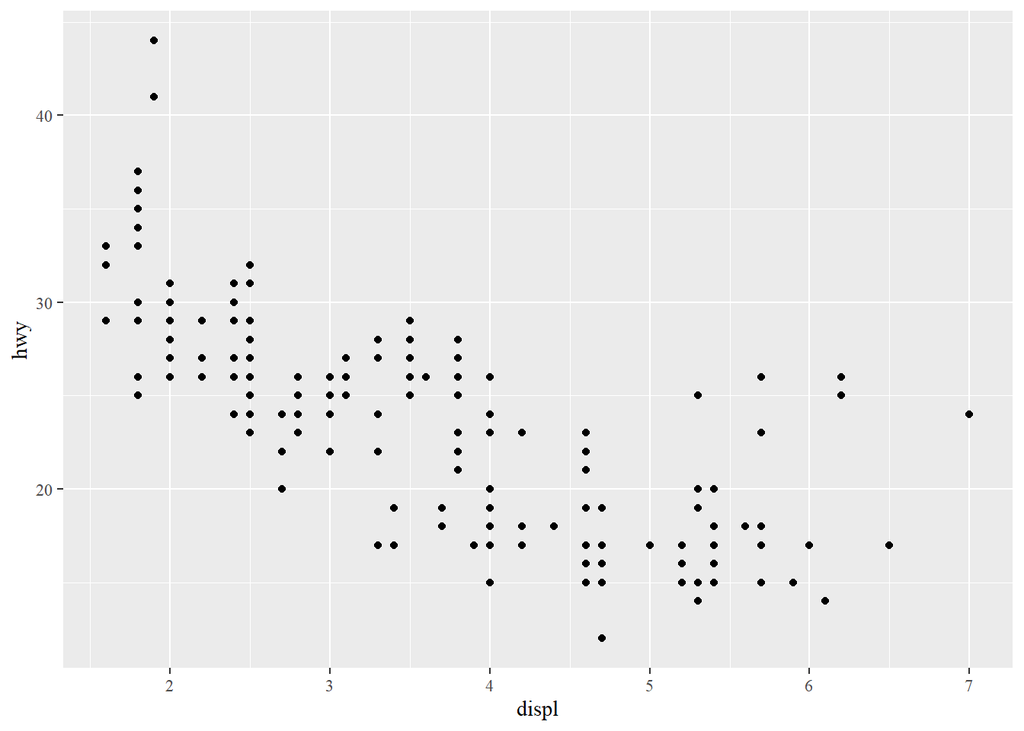

```r
mpg %>%
  ggplot(aes(displ,hwy)) +
  geom_point() +
  theme(text = element_text(family = "Times New Roman"))
```

## 映射

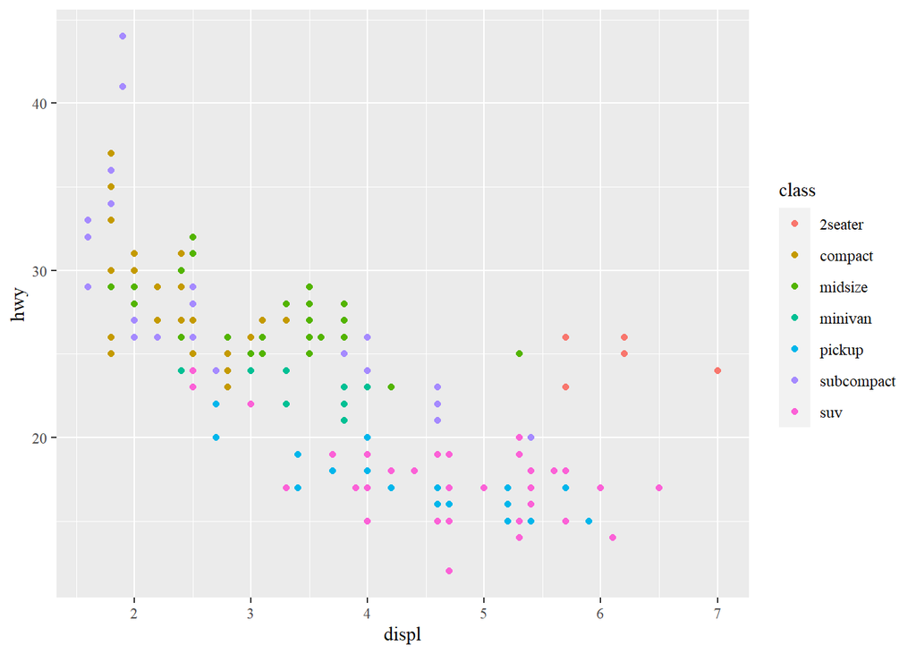

```r
mpg %>%
  ggplot() +
  geom_point(aes(displ,hwy,col = class)) +
  theme(text = element_text(family = "Times New Roman"))
```

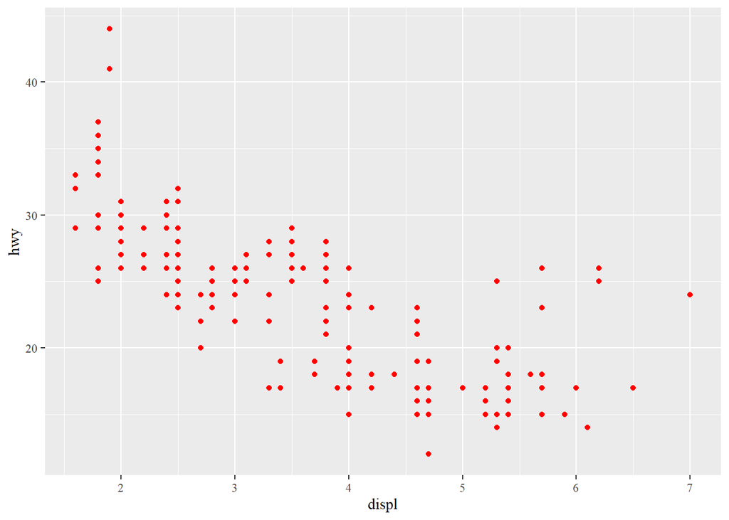

```r
ggplot(data = mpg,aes(displ,hwy)) +
  geom_point(col = "red") +
  theme(text = element_text(family = "Times New Roman"))
```

用数值1:25可以标识R的25种内置形状

```r
map_chr(mpg,class)
```

```
## manufacturer        model        displ         year          cyl        trans
##  "character"  "character"    "numeric"    "integer"    "integer"  "character"
##          drv          cty          hwy           fl        class
##  "character"    "integer"    "integer"  "character"  "character"
```

如果将图形属性映射为非变量名对象，比如 `aes(color = displ < 5)`，会发生什么情况？

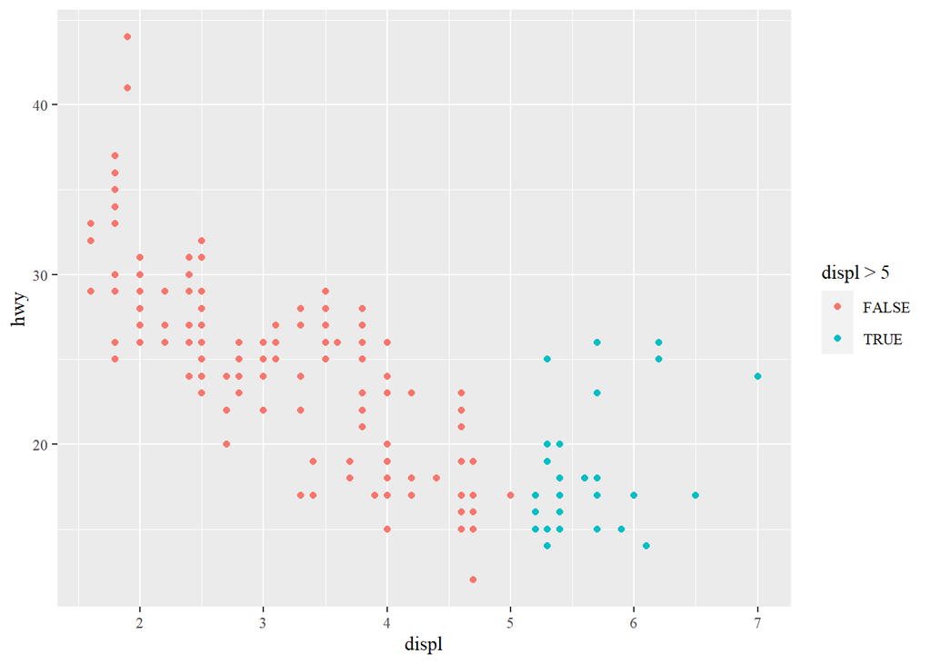

```r
mpg %>%
  ggplot(aes(displ,hwy)) +
  geom_point(aes(col = (displ > 5))) +
  theme(text = element_text(family = "Times New Roman")) +
  scale_color_discrete(name = "displ > 5")
```

通过在控制台中运行?函数名，或者**在RStudio中选定函数名称后按F1键**，你可以获得任何R函数的帮助信息。如果帮助页面看上去没什么用，也不要着急，你可以跳过这些帮助信息，向下找到示例部分，并查看与你的需求相匹配的代码.

## 分面

添加额外变量的一种方法是使用**图形属性**。另一种方法是将图分割成多个分面，即可以显示数据子集的子图。这种方法特别适合添加**分类变量**。

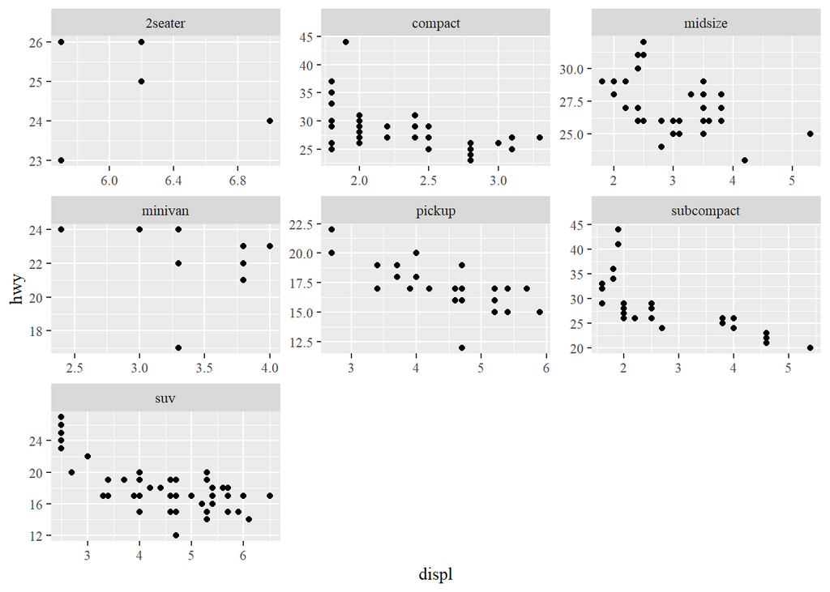

```r
mpg %>%
  ggplot(aes(displ,hwy)) +
  geom_point() +
  facet_wrap(~ class,scales = "free") +
    theme(text = element_text(family = "Times New Roman"))
```

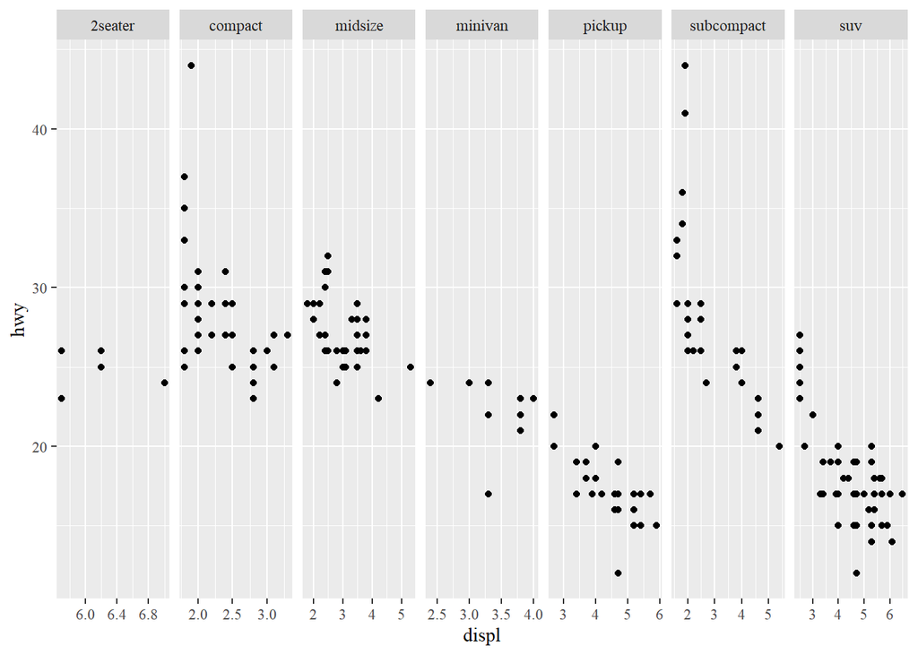

```r
mpg %>%
  ggplot(aes(displ,hwy)) +
  geom_point() +
  facet_grid(.~class,scales = "free") +
    theme(text = element_text(family = "Times New Roman"))
```

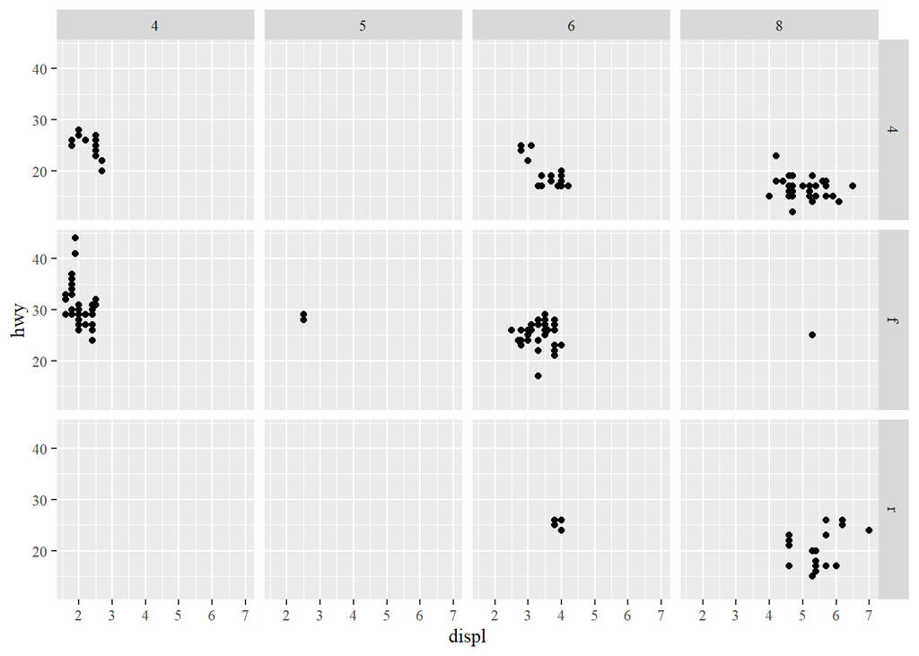

```r
ggplot(data = mpg) +
  geom_point(mapping = aes(x = displ, y = hwy)) +
  facet_grid(drv ~ cyl) +
  theme(text = element_text(family = "Times New Roman"))
```

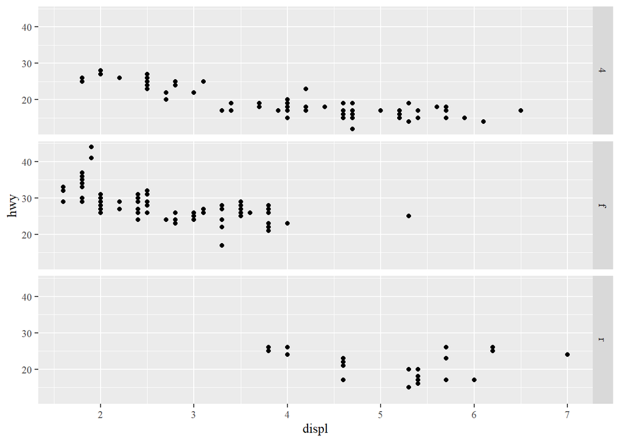

```r
ggplot(data = mpg) +
  geom_point(mapping = aes(x = displ, y = hwy)) +
  facet_grid(drv ~ .) +
  theme(text = element_text(family = "Times New Roman"))
```

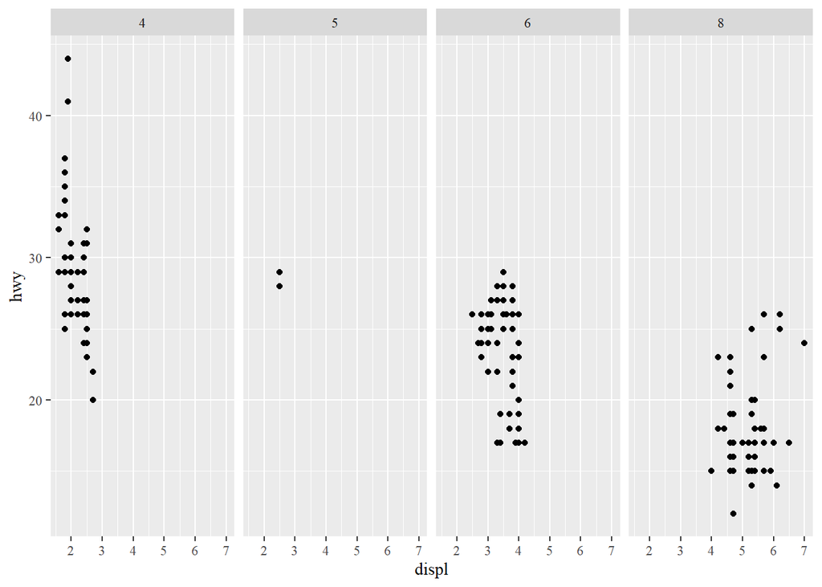

```r
ggplot(data = mpg) +
  geom_point(mapping = aes(x = displ, y = hwy)) +
  facet_grid(. ~ cyl) +
  theme(text = element_text(family = "Times New Roman"))
```

阅读 ?facet_wrap的帮助页面。nrow和ncol的功能分别是什么？还有哪些选项可以控制分面的布局？为什么函数facet_grid() 没有变量nrow和ncol ？

## 几何对象

ggplot2中的每个几何对象函数都有一个mapping参数。但是，不是每种图形属性都适合每种几何对象。你可以设置点的形状，但不能设置线的“形状”，而可以设置线的线型。

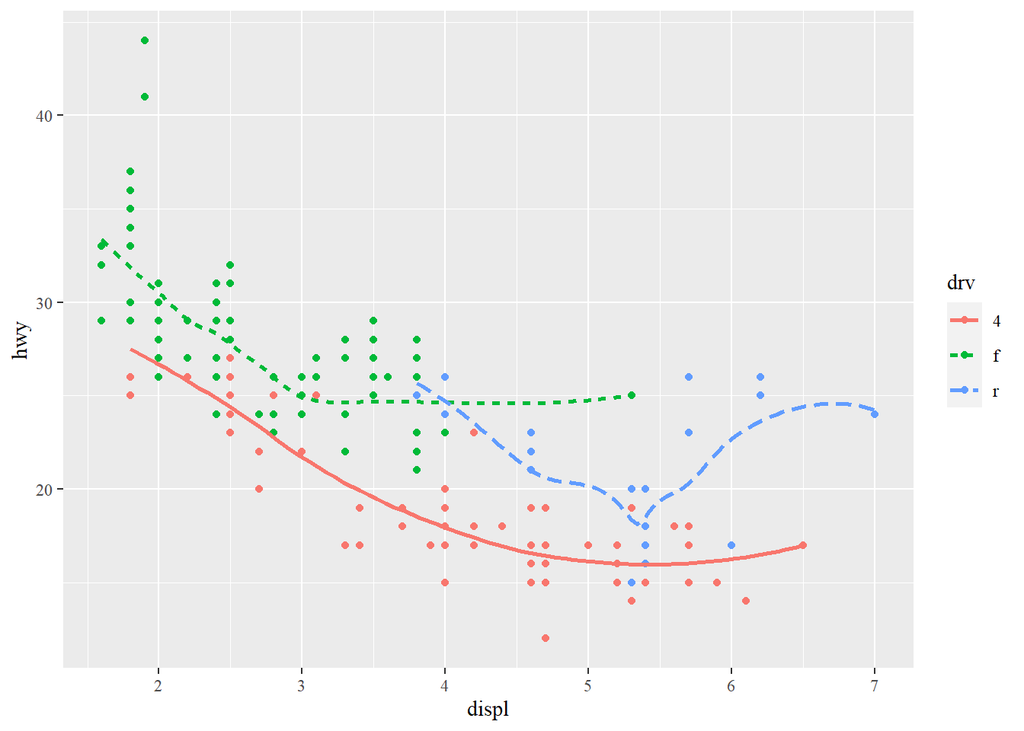

```r
mpg %>%
  ggplot(aes(displ,hwy)) +
  geom_point(aes(col = drv)) +
  geom_smooth(aes(col = drv,linetype = drv),se = FALSE) +
  theme(text = element_text(family = "Times New Roman"))
```

根据表示汽车驱动系统的drv变量的值，这里的geom_smooth()函数分别用3条曲线来表示汽车。一条线表示drv值为4的所有汽车，一条线表示drv值为f的所有汽车，另一条线表示drv值为r的所有汽车。其中4表示四轮驱动，f表示前轮驱动，r表示后轮驱动。

ggplot2提供了30多种几何对象，其扩展包甚至提供了更多（可以在https://www.ggplot2-exts.org上查看更多样例）。如果想全面地了解这些对象，最好的方式是学习ggplot2速查表（参见http://rstudio.com/cheatsheets）。如果想掌握更多关于某个几何对象的知识，那么可以使用帮助，如`?geom_smooth`。

```r
ggplot(data = mpg) +
  geom_point(aes(displ,hwy)) +
  geom_smooth(aes(displ,hwy),se = FALSE) +
  theme(text = element_text(family = "Times New Roman"))->p1

mpg %>%
  ggplot(aes(displ,hwy,group = drv)) +
  geom_point() +
  geom_smooth(se = FALSE) +
  theme(text = element_text(family = "Times New Roman"))->p2
```

```r
mpg %>%
  ggplot(aes(displ,hwy,col = drv)) +
  geom_point() +
  geom_smooth(se = FALSE) +
  theme(text = element_text(family = "Times New Roman"))->p3

mpg %>%
  ggplot(aes(displ,hwy)) +
  geom_point(aes(col = drv)) +
  geom_smooth(se = FALSE) +
  theme(text = element_text(family = "Times New Roman"))->p4
```

```r
mpg %>%
  ggplot(aes(displ,hwy)) +
  geom_point(aes(col = drv)) +
  geom_smooth(aes(linetype = drv),se = FALSE) +
  theme(text = element_text(family = "Times New Roman"))->p5

mpg %>%
  ggplot(aes(displ,hwy)) +
  geom_point(aes(col = drv)) +
  theme(text = element_text(family = "Times New Roman"))->p6
```

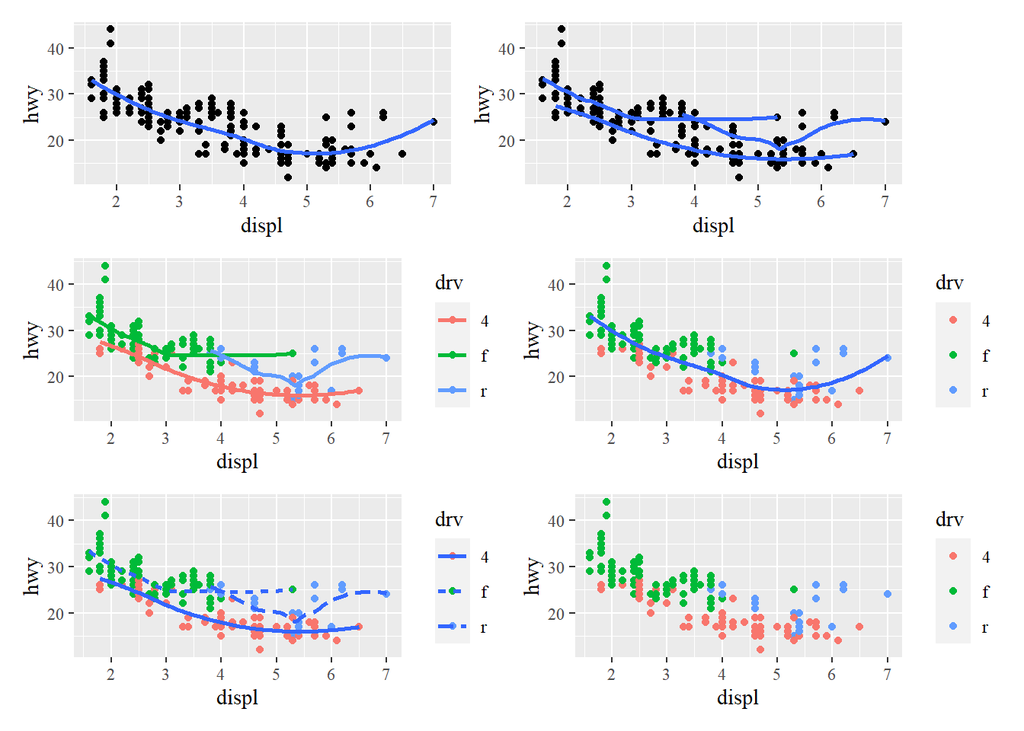

```r
(p1 + p2)/( p3 + p4) / (p5 + p6 )
```

## 统计变换

```r
diamonds$cut %>% class()
```

```
## [1] "ordered" "factor"
```

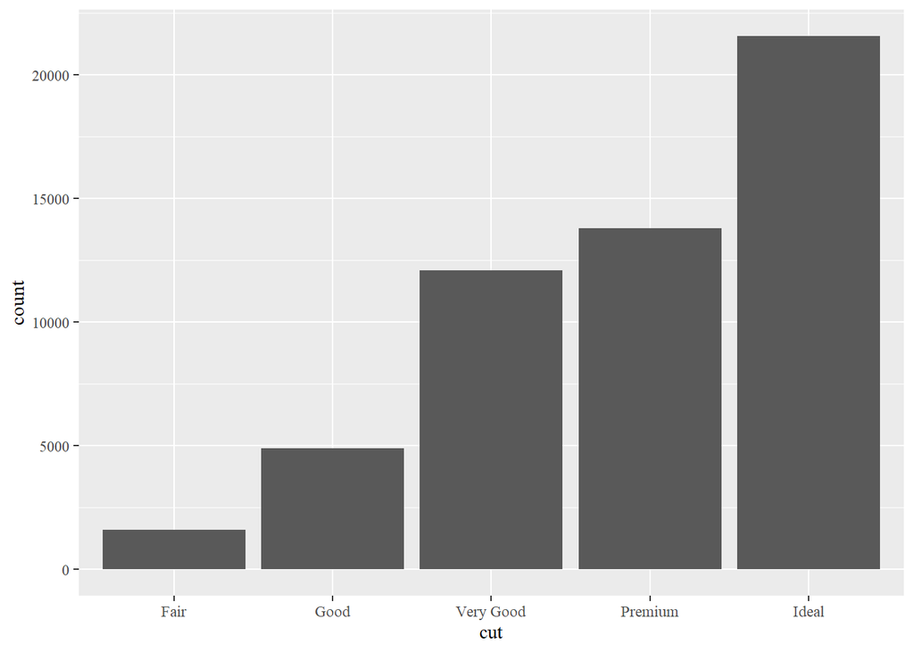

```r
diamonds %>%
  ggplot() +
  geom_bar(aes(cut)) +
  theme(text = element_text(family = "Times New Roman"))
```

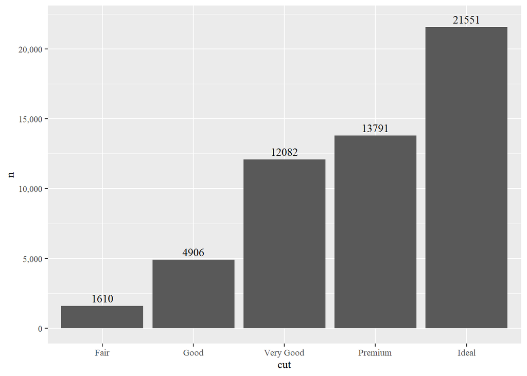

```r
diamonds %>%
  group_by(cut) %>%
  count() %>%
  ungroup() %>%
  mutate(number = n,prop = n/sum(n))->data_diamonds

data_diamonds %>%
  ggplot() +
  geom_col(aes(cut,n)) +
  geom_text(aes(cut,n,label = n),
            vjust = -0.5,
            family = "Times New Roman") +
  scale_y_continuous(limits = c(0,22000),labels = scales::comma) +
  theme(text = element_text(family = "Times New Roman"))
```

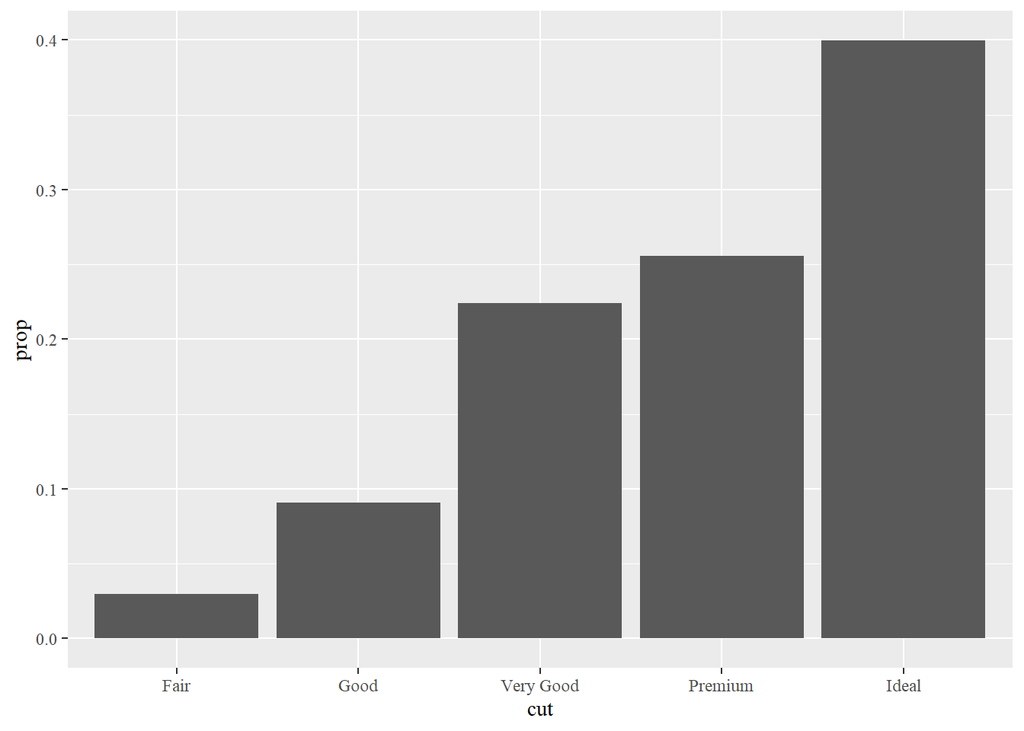

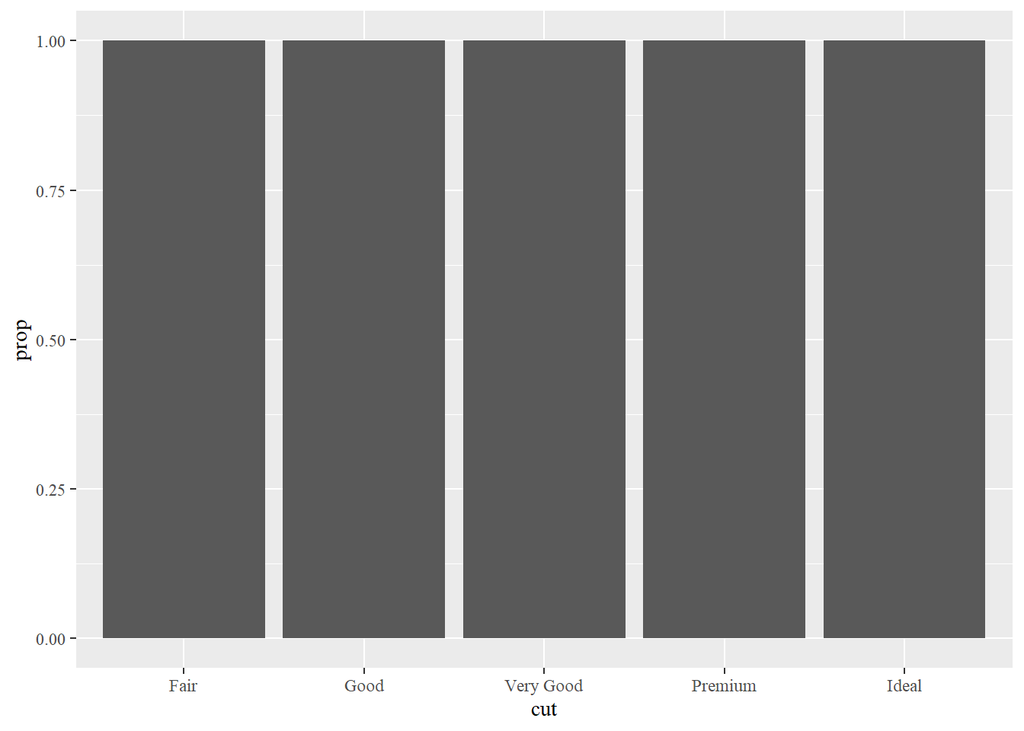

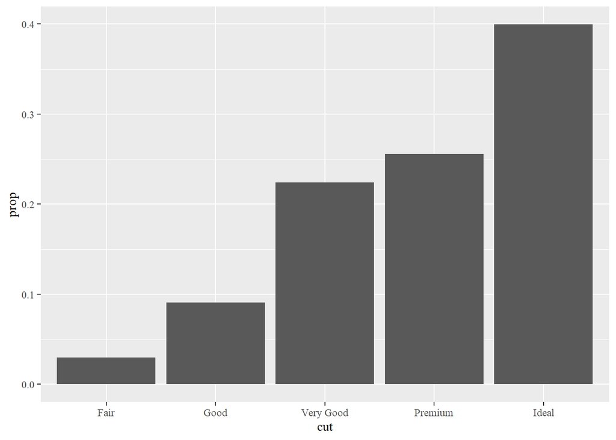

```r
ggplot(data = diamonds) +
  geom_bar(mapping = aes(x = cut, y = ..prop..,group = 1)) +
  theme(text = element_text(family = "Times New Roman"))

ggplot(data = diamonds) +
  geom_bar(mapping = aes(x = cut, y = ..prop..)) +
  theme(text = element_text(family = "Times New Roman"))

ggplot(data = diamonds) +
  geom_bar(mapping = aes(x = cut,
                         fill = color,
                         y = ..prop..,
                         group= 1)) +
  theme(text = element_text(family = "Times New Roman"))
```

## 位置调整

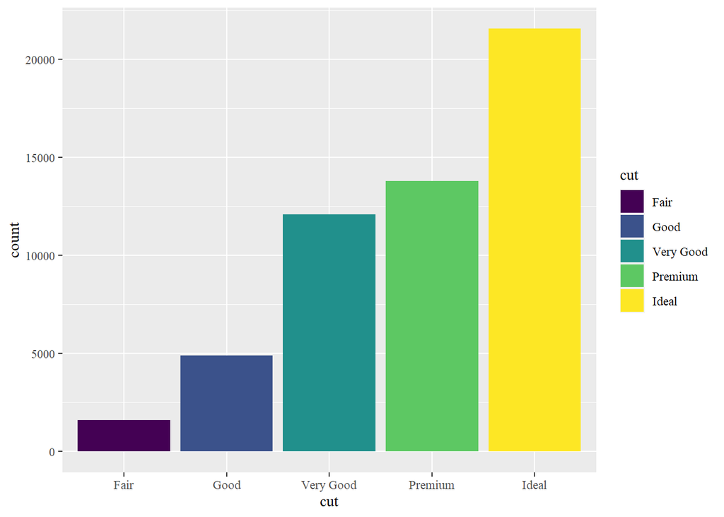

```r
diamonds %>%
  ggplot(aes(x = cut,fill = cut)) +
  geom_bar() +
  theme(text = element_text(family = "Times New Roman"))
```

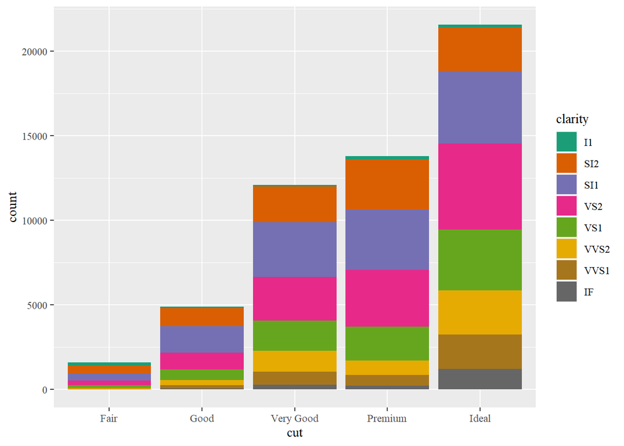

```r
diamonds %>%
  ggplot(aes(x = cut)) +
  geom_bar(aes(fill = clarity)) +
  theme(text = element_text(family = "Times New Roman")) +
  scale_fill_brewer(palette = "Dark2")
```

这种堆叠是由position参数设定的位置调整功能自动完成的。如果不想生成堆叠式条形图，你还可以使用以下3种选项之一： **“identity”、 “fill” 和 “dodge”**。

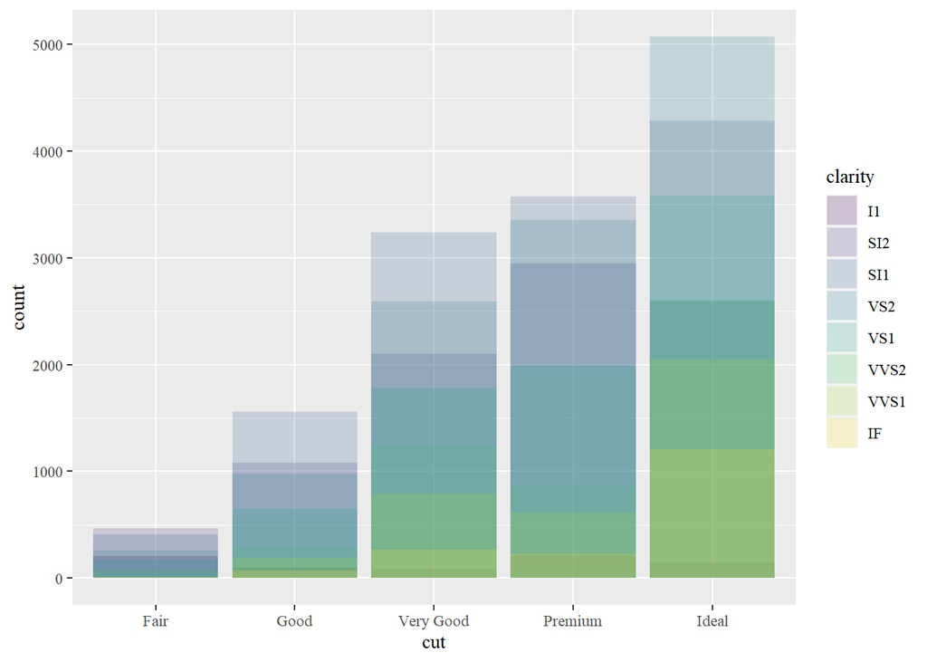

```r
ggplot(data = diamonds,
       mapping = aes(x = cut, fill = clarity)) +
  geom_bar(alpha = 1 / 5, position = "identity") +
  theme(text = element_text(family = "Times New Roman"))
```

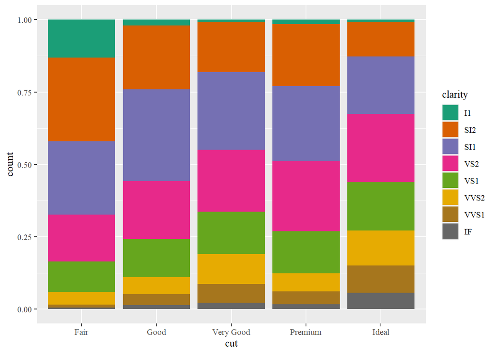

```r
ggplot(data = diamonds) +
  geom_bar(mapping = aes(x = cut, fill = clarity),
           position = "fill") +
  theme(text = element_text(family = "Times New Roman")) +
  scale_fill_brewer(palette = "Dark2")
```

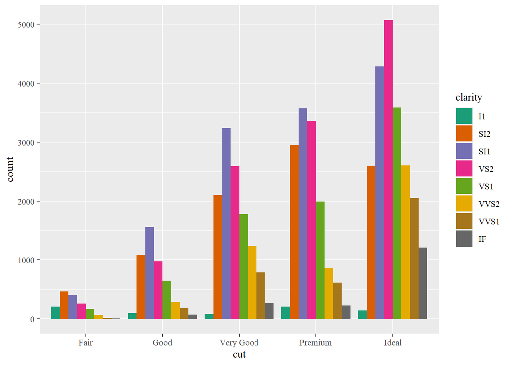

```r
ggplot(data = diamonds) +
  geom_bar(mapping = aes(x = cut, fill = clarity),
           position = "dodge") +
  theme(text = element_text(family = "Times New Roman")) +
  scale_fill_brewer(palette = "Dark2")
```

## 坐标系

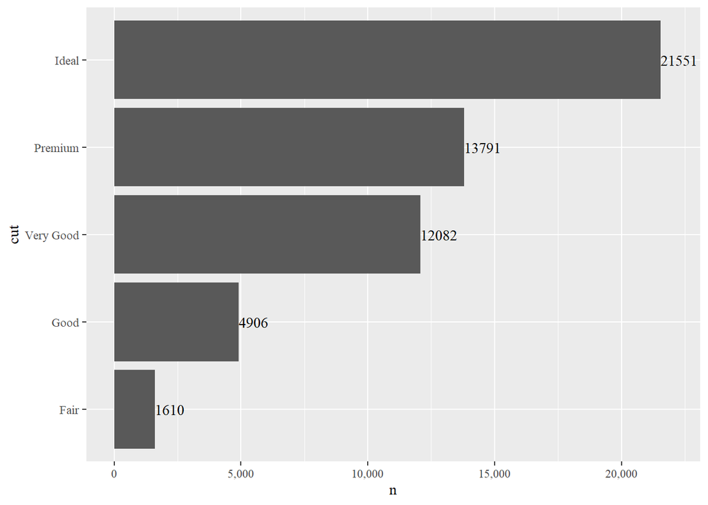

```r
data_diamonds %>%
  ggplot() +
  geom_col(aes(cut,n)) +
  geom_text(aes(cut,n,label = n),
            hjust = 0,
            family = "Times New Roman") +
  scale_y_continuous(limits = c(0,22000),labels = scales::comma) +
  theme(text = element_text(family = "Times New Roman")) +
  coord_flip()
```

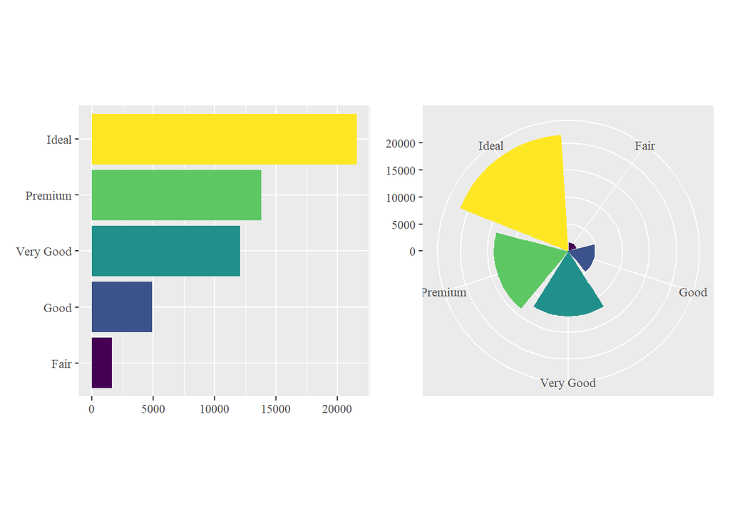

```r
bar <- ggplot(data = diamonds) +
  geom_bar(
    mapping = aes(x = cut, fill = cut),
    show.legend = FALSE
    # width = 1
  ) +
  theme(aspect.ratio = 1) +
  theme(text = element_text(family = "Times New Roman")) +
  labs(x = NULL, y = NULL)
(bar + coord_flip())|(bar + coord_polar())
```

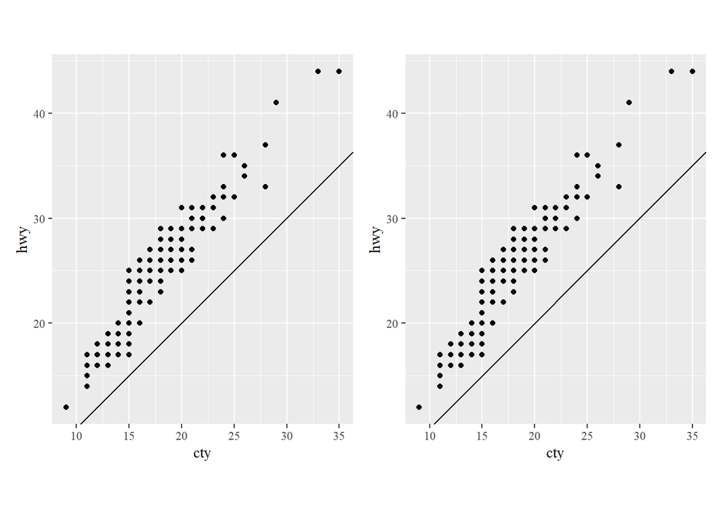

```r
ggplot(data = mpg,
       mapping = aes(x = cty, y = hwy)) +
  geom_point() +
  geom_abline() +
  coord_fixed() +
  theme(text = element_text(family = "Times New Roman"))->p1
ggplot(data = mpg,
       mapping = aes(x = cty, y = hwy)) +
  geom_point() +
  geom_abline() +
  theme(text = element_text(family = "Times New Roman"))->p2
(p1 + p2)
```

用于建立图形的一个正式语法系统。你可以将任何图形精确地描述为**数据集**、**几何对象**、**映射集合**、**统计变换**、**位置调整**、**坐标系**和**分面模式**的一个组合，图形语法正是基于这样的深刻理解构建出来的。

## 标签

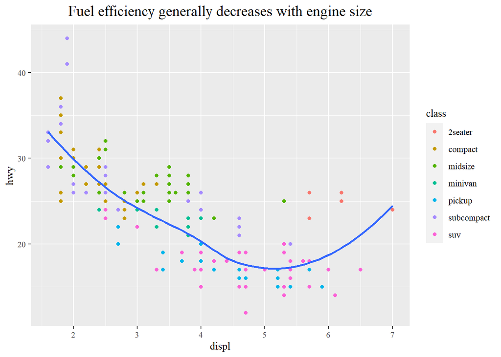

```r
ggplot(mpg, aes(displ, hwy)) +
  geom_point(aes(color = class)) +
  geom_smooth(se = FALSE) +
  labs(title = paste("Fuel efficiency generally decreases with",
                     "engine size")) +
  theme(text = element_text(family = "Times New Roman")) +
  theme(plot.title = element_text(hjust = 0.5,size = 15))
```

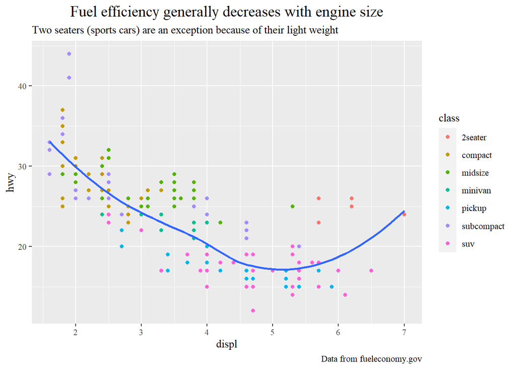

```r
ggplot(mpg, aes(displ, hwy)) +
  geom_point(aes(color = class)) +
  geom_smooth(se = FALSE) +
  labs(
    title = paste("Fuel efficiency generally decreases with",
                  "engine size"),
    subtitle = paste(
      "Two seaters (sports cars) are an exception",
      "because of their light weight"
    ),
    caption = "Data from fueleconomy.gov"
  ) +
  theme(text = element_text(family = "Times New Roman")) +
  theme(plot.title = element_text(hjust = 0.5,size = 15))
```

## 注释

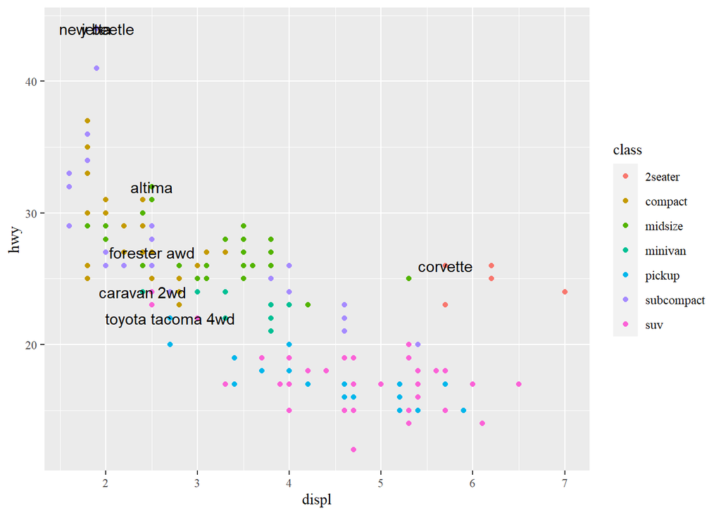

```r
best_in_class <- mpg %>%
  group_by(class) %>%
  filter(row_number(desc(hwy)) == 1) %>%
  ungroup()
# or
mpg %>%
  group_by(class) %>%
  arrange(-hwy) %>%
  slice(1) %>%
  ungroup()->best_in_class1

ggplot(mpg, aes(displ, hwy)) +
  geom_point(aes(color = class)) +
  geom_text(aes(label = model), data = best_in_class1) +
  theme(text = element_text(family = "Times New Roman")) +
  theme(plot.title = element_text(hjust = 0.5,size = 15))
```

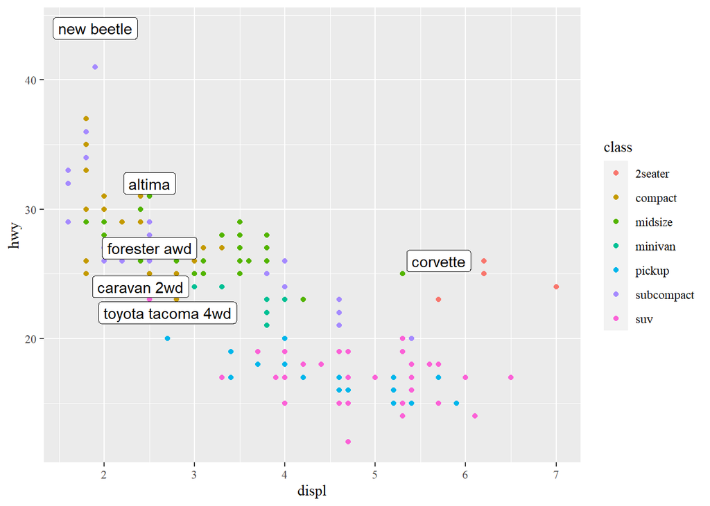

```r
ggplot(mpg, aes(displ, hwy)) +
  geom_point(aes(color = class)) +
  geom_label(aes(label = model), data = best_in_class) +
  theme(text = element_text(family = "Times New Roman")) +
  theme(plot.title = element_text(hjust = 0.5,size = 15))
```

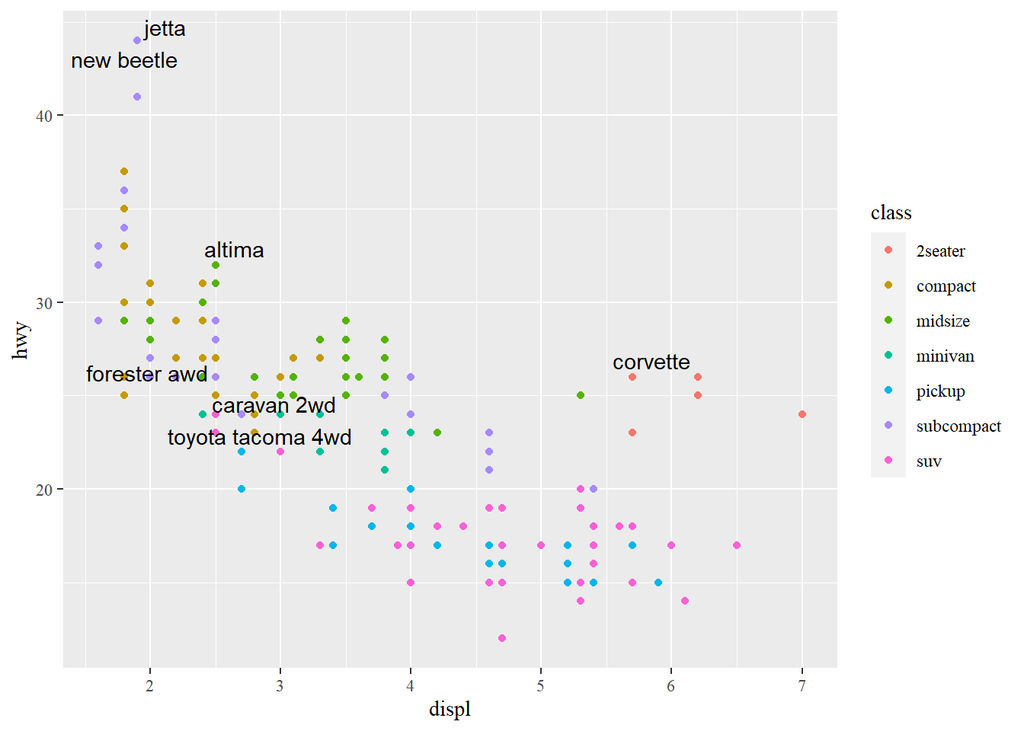

```r
ggplot(mpg, aes(displ, hwy)) +
  geom_point(aes(color = class)) +
  ggrepel::geom_text_repel(aes(label = model), data = best_in_class) +
  theme(text = element_text(family = "Times New Roman")) +
  theme(plot.title = element_text(hjust = 0.5,size = 15))
```

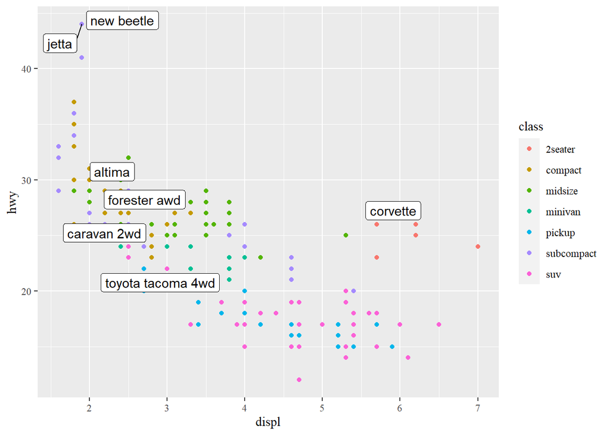

```r
ggplot(mpg, aes(displ, hwy)) +
  geom_point(aes(color = class)) +
  ggrepel::geom_label_repel(aes(label = model), data = best_in_class) +
  theme(text = element_text(family = "Times New Roman")) +
  theme(plot.title = element_text(hjust = 0.5,size = 15))
```

## 标度

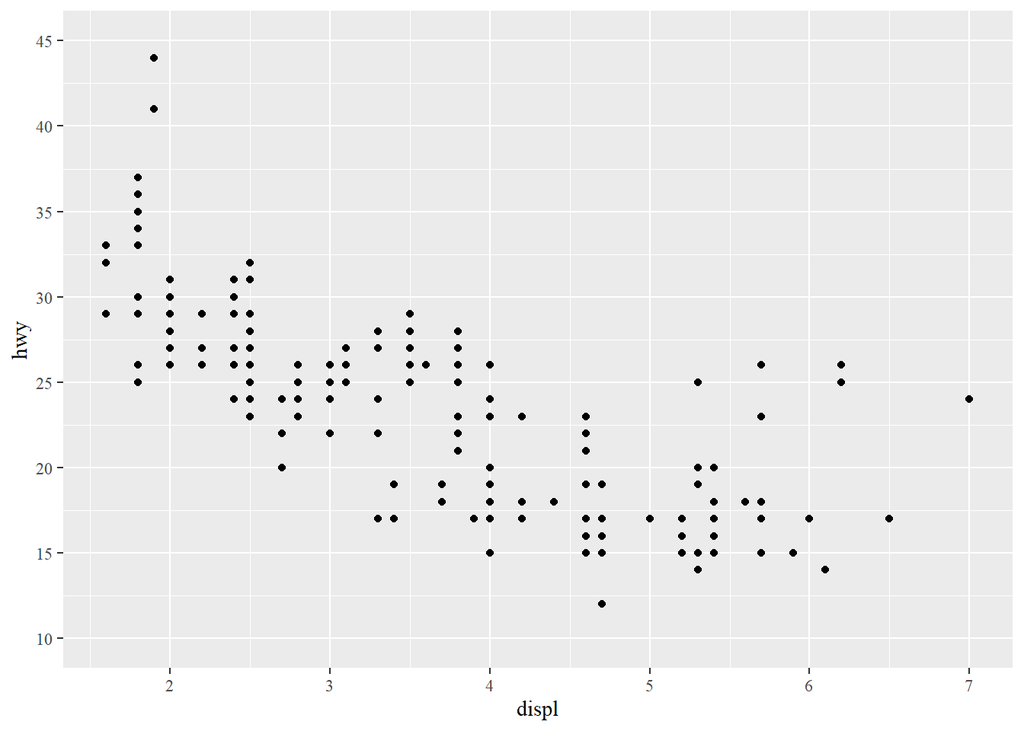

```r
mpg %>%
  ggplot(aes(displ,hwy)) +
  geom_point() +
  scale_y_continuous(breaks = seq(10,45,5),limits = c(10,45)) +
  theme(text = element_text(family = "Times New Roman")) +
  theme(plot.title = element_text(hjust = 0.5,size = 15))
```

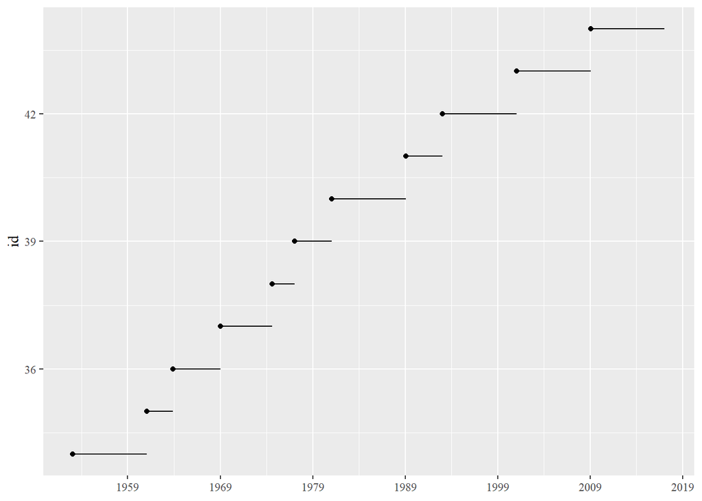

```r
presidential %>%
  mutate(id = 33 + row_number()) %>%
  ggplot(aes(start, id)) +
  geom_point() +
  geom_segment(aes(xend = end,yend = id)) +
  scale_x_date(name = NULL,
               date_breaks = "10 years",
               date_labels = "%Y") +
  theme(text = element_text(family = "Times New Roman")) +
  theme(plot.title = element_text(hjust = 0.5,size = 15))
```

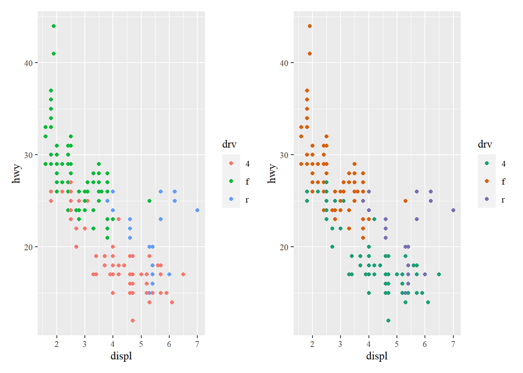

```r
ggplot(mpg, aes(displ, hwy)) +
  geom_point(aes(color = drv)) +
  theme(text = element_text(family = "Times New Roman")) +
  theme(plot.title = element_text(hjust = 0.5,size = 15))->p1

ggplot(mpg, aes(displ, hwy)) +
  geom_point(aes(color = drv)) +
  scale_color_brewer(palette = "Dark2") +
  theme(text = element_text(family = "Times New Roman")) +
  theme(plot.title = element_text(hjust = 0.5,size = 15))->p2

p1|p2
```

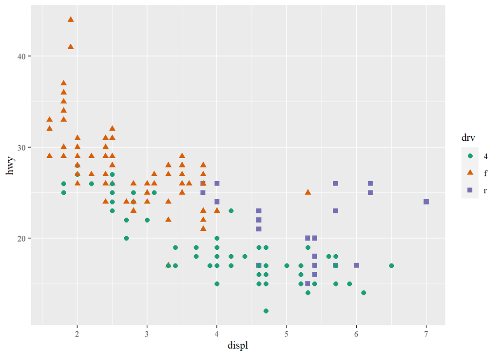

```r
mpg %>%
  ggplot(aes(displ,hwy)) +
  geom_point(aes(col = drv,shape = drv), size= 2) +
  theme(text = element_text(family = "Times New Roman")) +
  theme(plot.title = element_text(hjust = 0.5,size = 15)) +
  scale_color_brewer(palette = "Dark2")
```

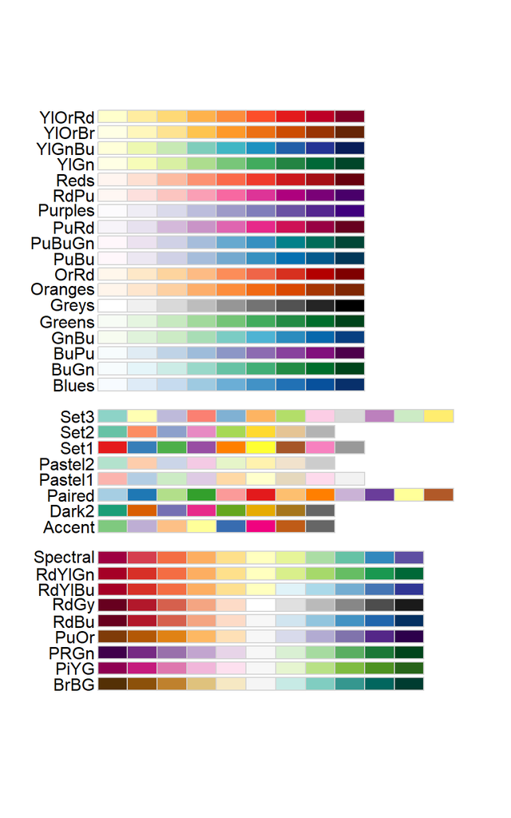

```r
RColorBrewer::display.brewer.all()
```

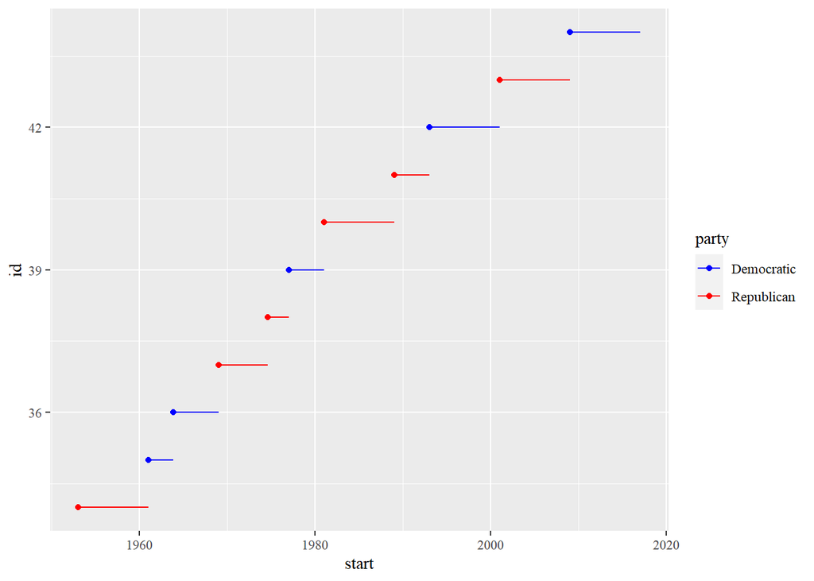

```r
presidential %>%
  mutate(id = 33 + row_number()) %>%
  ggplot(aes(start, id, color = party)) +
  geom_point() +
  geom_segment(aes(xend = end, yend = id)) +
  scale_colour_manual(values = c(Republican = "red",
                                 Democratic = "blue")) +
  theme(text = element_text(family = "Times New Roman")) +
  theme(plot.title = element_text(hjust = 0.5,size = 15))
```

## 图例

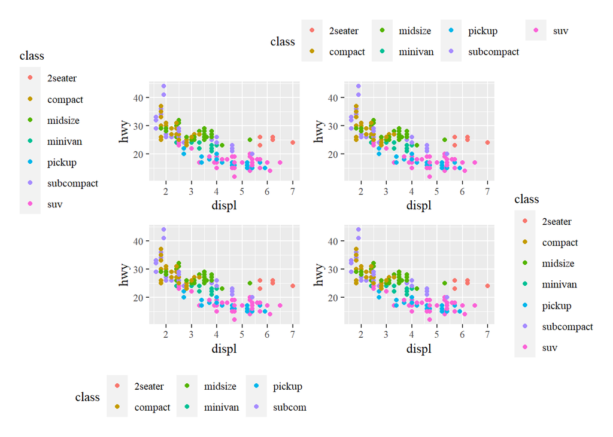

```r
base <- ggplot(mpg, aes(displ, hwy)) +
  geom_point(aes(color = class)) +
  theme(text = element_text(family = "Times New Roman")) +
  theme(plot.title = element_text(hjust = 0.5,size = 15))

base + theme(legend.position = "left")->p1
base + theme(legend.position = "top")->p2
base + theme(legend.position = "bottom")->p3
base + theme(legend.position = "right") ->p4

(p1 + p2)/ (p3 +p4)
```

要想控制单个图例的显示，可以配合`guide_legend()`或`guide_colorbar()函数`来使用`guides()函数`。

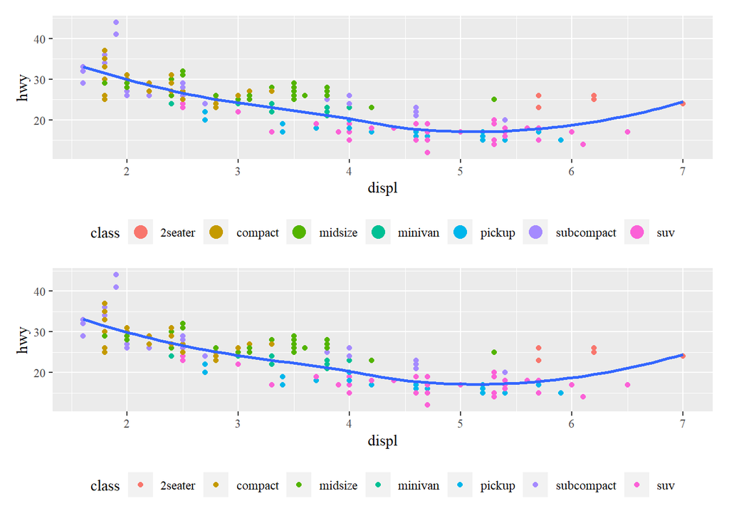

```r
ggplot(mpg, aes(displ, hwy)) +
  geom_point(aes(color = class)) +
  geom_smooth(se = FALSE) +
  theme(legend.position = "bottom") +
  guides(color = guide_legend(nrow = 1,
                              override.aes = list(size = 4)))+
  theme(text = element_text(family = "Times New Roman")) +
  theme(plot.title = element_text(hjust = 0.5,size = 15))->p1

ggplot(mpg, aes(displ, hwy)) +
  geom_point(aes(color = class)) +
  geom_smooth(se = FALSE) +
  theme(legend.position = "bottom") +
  guides(color = guide_legend(nrow = 1))+
  theme(text = element_text(family = "Times New Roman")) +
  theme(plot.title = element_text(hjust = 0.5,size = 15))->p2

p1/p2
```

## 缩放

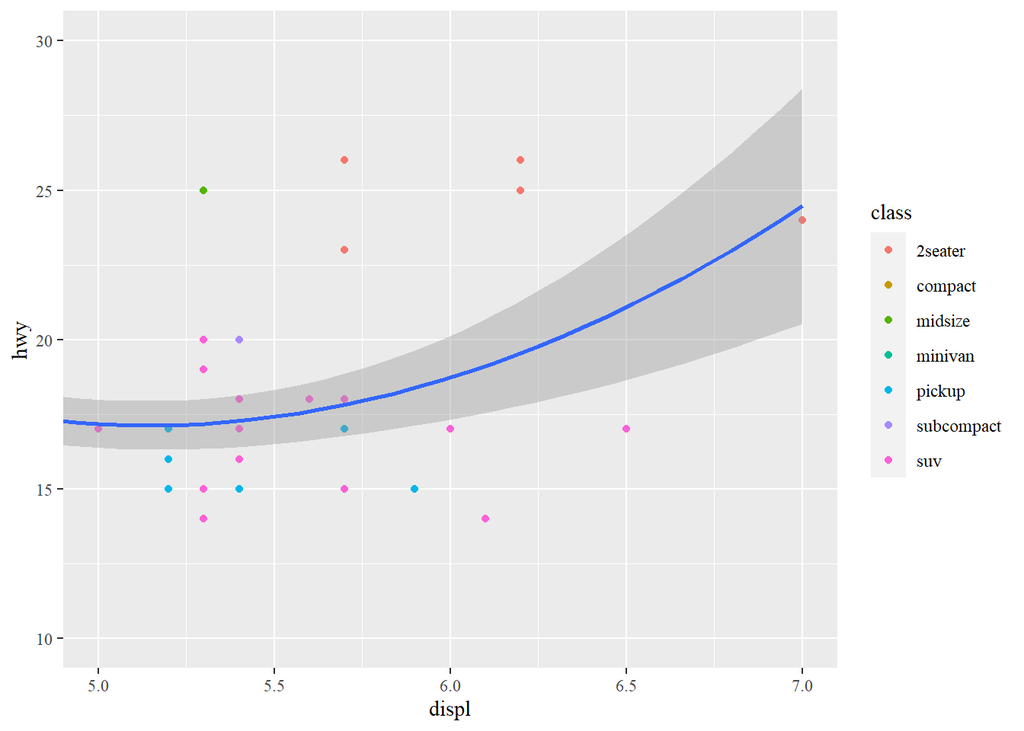

```r
ggplot(mpg, mapping = aes(displ, hwy)) +
  geom_point(aes(color = class)) +
  geom_smooth() +
  coord_cartesian(xlim = c(5, 7), ylim = c(10, 30)) +
  theme(text = element_text(family = "Times New Roman")) +
  theme(plot.title = element_text(hjust = 0.5,size = 15))
```

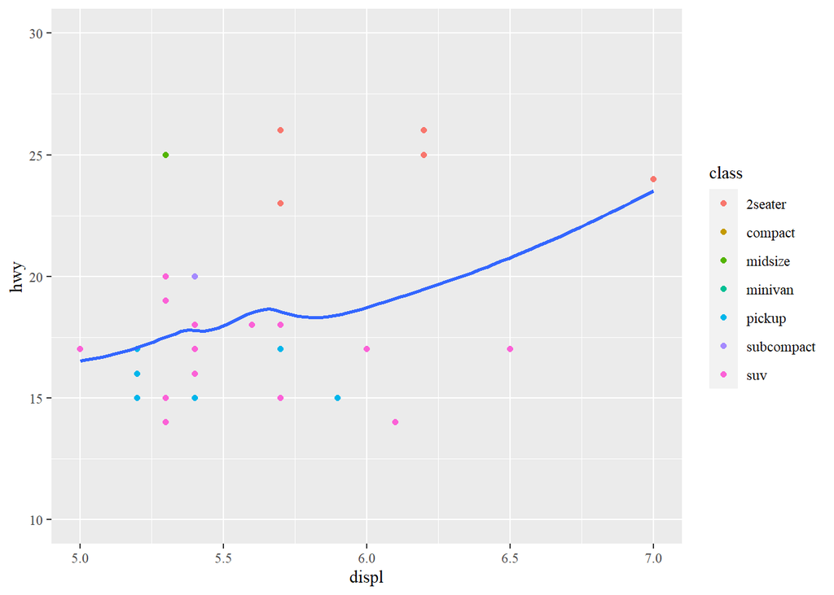

```r
mpg %>%
  ggplot(aes(displ,hwy)) +
  geom_point(aes(col = class)) +
  geom_smooth(se = FALSE) +
  xlim(5,7) +
  ylim(10,30) +
  theme(text = element_text(family = "Times New Roman")) +
  theme(plot.title = element_text(hjust = 0.5,size = 15))
```

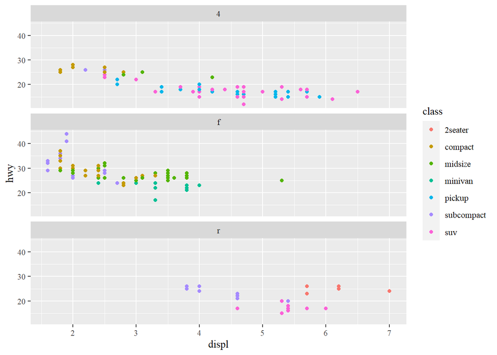

```r
mpg %>%
  ggplot(aes(displ,hwy)) +
  geom_point(aes(col = class)) +
  facet_wrap(~drv,nrow = 3) +
  theme(text = element_text(family = "Times New Roman")) +
  theme(plot.title = element_text(hjust = 0.5,size = 15))
```

## 主题

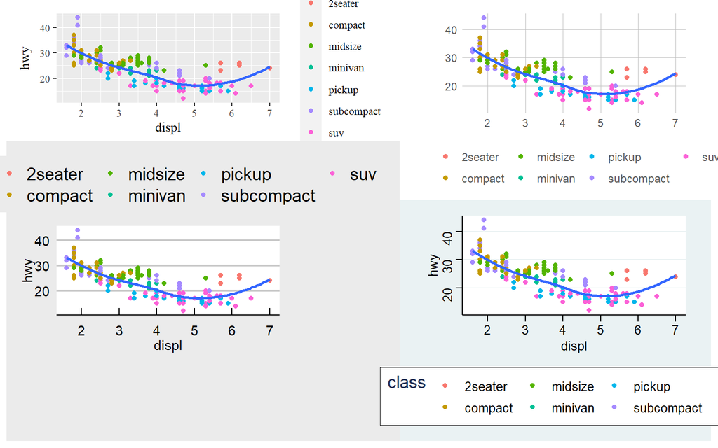

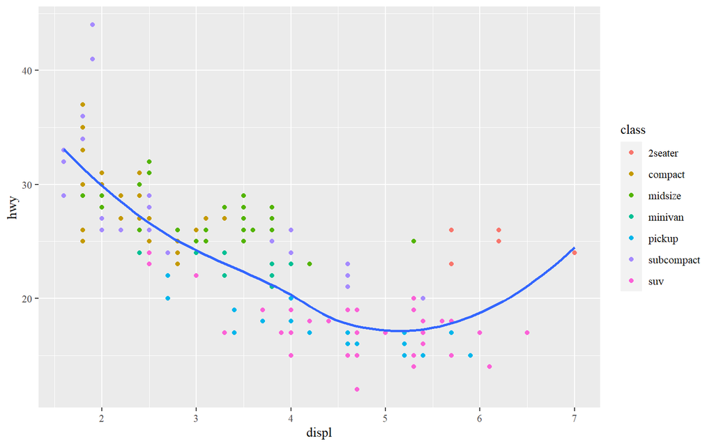

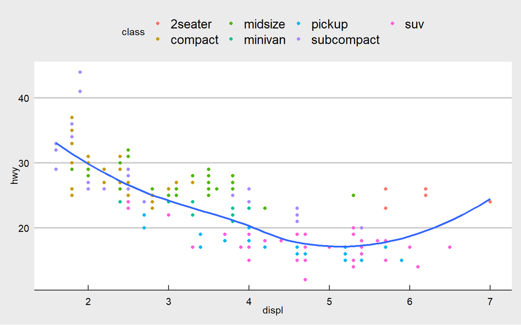

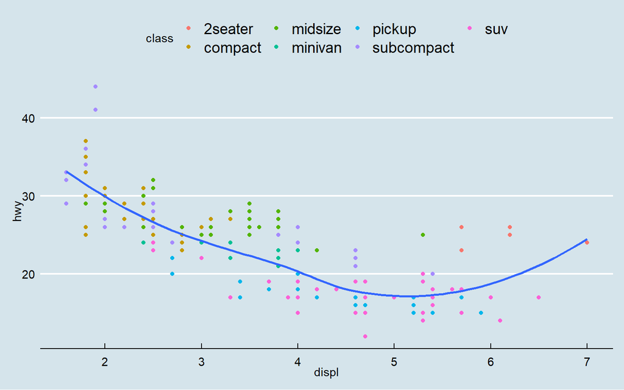

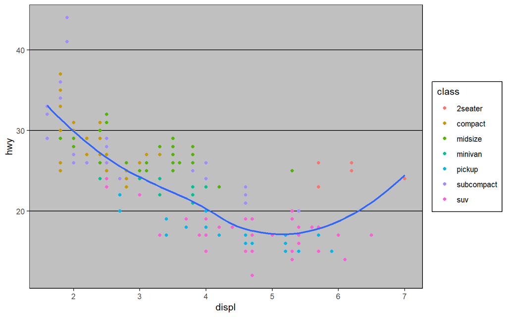

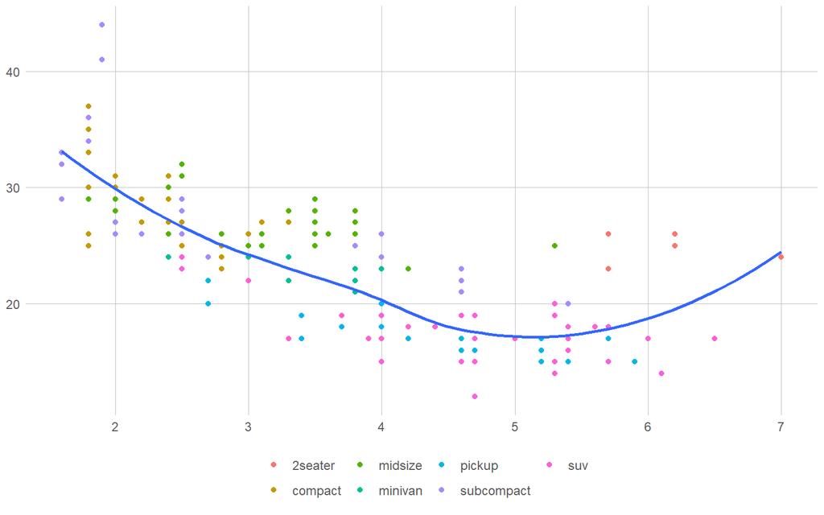

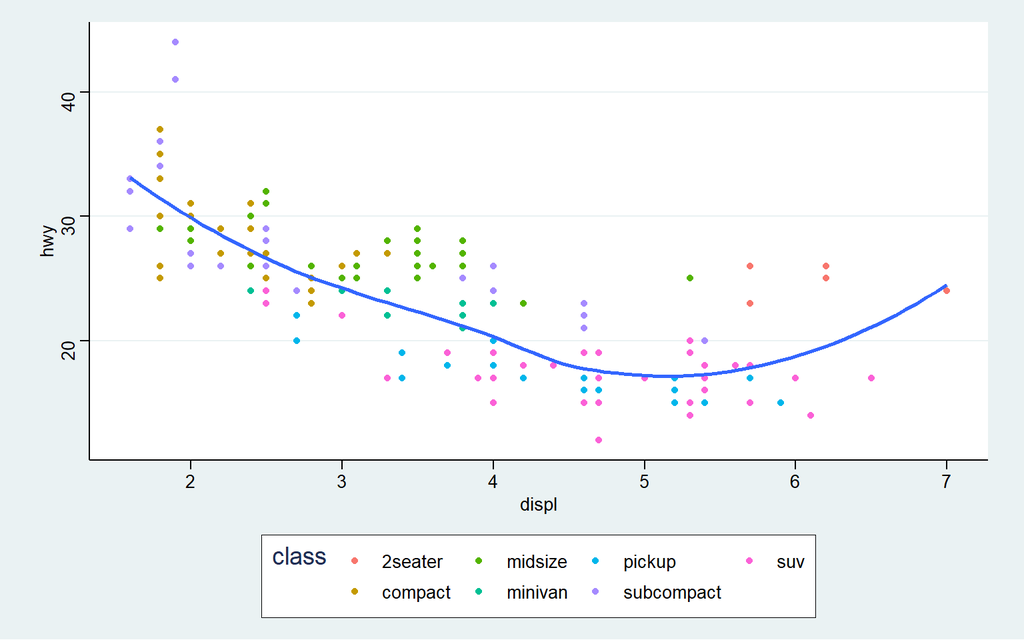

```r
ggplot(mpg, aes(displ, hwy)) +
  geom_point(aes(color = class)) +
  geom_smooth(se = FALSE) +
  theme(text = element_text(family = "Times New Roman")) +
  theme(plot.title = element_text(hjust = 0.5,size = 15))->p1
ggplot(mpg, aes(displ, hwy)) +
  geom_point(aes(color = class)) +
  geom_smooth(se = FALSE) +
  theme(text = element_text(family = "Times New Roman")) +
  theme(plot.title = element_text(hjust = 0.5,size = 15)) +
  ggthemes::theme_economist_white()->p2
ggplot(mpg, aes(displ, hwy)) +
  geom_point(aes(color = class)) +
  geom_smooth(se = FALSE) +
  theme(text = element_text(family = "Times New Roman")) +
  theme(plot.title = element_text(hjust = 0.5,size = 15)) +
  ggthemes::theme_economist()->p3
ggplot(mpg, aes(displ, hwy)) +
  geom_point(aes(color = class)) +
  geom_smooth(se = FALSE) +
  theme(text = element_text(family = "Times New Roman")) +
  theme(plot.title = element_text(hjust = 0.5,size = 15))+
  ggthemes::theme_excel()->p4
ggplot(mpg, aes(displ, hwy)) +
  geom_point(aes(color = class)) +
  geom_smooth(se = FALSE) +
  theme(text = element_text(family = "Times New Roman")) +
  theme(plot.title = element_text(hjust = 0.5,size = 15))+
  ggthemes::theme_excel_new()->p5
ggplot(mpg, aes(displ, hwy)) +
  geom_point(aes(color = class)) +
  geom_smooth(se = FALSE) +
  theme(text = element_text(family = "Times New Roman")) +
  theme(plot.title = element_text(hjust = 0.5,size = 15))+
  ggthemes::theme_stata()->p6

(p1/p2)|(p5/p6)
p1
p2
p3
p4
p5
p6
```

## 保存图片

在RMarkdown中，关于图形的最大问题是如何确定其大小和形状。控制图形大小的选项主要有5个：`fig.width`、`fig.height`、`fig.asp`、`out.width`和`out.height`。之所以说图形大小是一个难题，是因为图形大小有两种（R生成的图形的大小，以及插入到输出文档中的图形的大小），而且指定图形大小的方法也有多种（即高度、宽度和高宽比：三者任选其二）。

我们发现，宽度一致的图形是最令人赏心悦目的。为了使图形宽度保持一致，我们设置图形的默认参数为`fig.width`=6（6英寸）和`fig.asp`=0.618（黄金分割）。在单个代码段中，我们只调整`fig.asp`.

我们使用`out.width`控制输出图形的大小，并将其设置为行宽的百分比。默认设置为`out.width`=“70%”和`fig.align`=“center”。这样一来，图形既不会占用过多空间，也不会显得太拥挤.

如果想在一行中放置多个图形，可以将`out.width`设置为50%以放置2个图形、设置为33%以放置3个图形，或者设置为25%以放置4个图形，同时还要设置`fig.align` =“default”。

如果你发现必须眯起眼睛才能看清图形上的文本，那么就需要调整`fig.width`参数。如果`fig.width`大于最终文档中的图形的尺寸，那么文本就会显得过小；如果`fig.width`小于最终文档中的图形的尺寸，那么文本就会显得过大。一般来说，你需要试验几次才能找到`fig.width`和最终文档中的图形的最佳比例。

如果想要让所有图形中的字体都保持一致大小，那么只要设置了`out.width`，就同时还需要调整`fig.width`，使其与默认`out.width`保持同样的比例。例如，如果默认`fig.width`为6，`out.width`为 0.7，那么当设置 `out.width` = “50%” 时，你需要同时将 `fig.width` 设置为4.3（6*0.5/0.7）。